```python
import librosa
import numpy as np
import pandas as pd
import matplotlib.pyplot as plt
from matplotlib.pyplot import imshow
import scipy.stats as stats
from PIL import Image
from matplotlib.image import imread
import math
import scipy
import scipy.io
import sys
import random
import copy
import IPython.display as ipd
from numpy import linalg
```

# P1: Optimal K for PLSI

1. It is known that there are different ways to express one’s feelings using emoticons depending on the culture. For example, in Korea, where I’m from, we use double circumflexes to represent a smiley face, e.g., (ˆˆ). On the other hand, an angry face can be represented by (` ́). Note that lips are not necessary.
1. I found though in the western culture people recognize someone’s feeling via the lip shapes, e.g., :) or :(. I have no problem with these emoticons except that they are rotated by 90 degrees (kinda weird to me). After realizing this difference, in my real life, I’m trying to smile by moving my lips instead of using eyes to better communicate my friends from the western culture.
1. faces.npy (or faces.mat if you have to use MATLAB) contains eight different human faces, each of which is a vectorized 2D array. If you reshape one of the 441 dimensional vectors into a 21 × 21 2D array, and then display it (e.g., using the imshow function), you will see a picture. Draw all eight faces in this way and include to your solution.

```python
X = np.load('faces.npy')
```

#### Eight faces

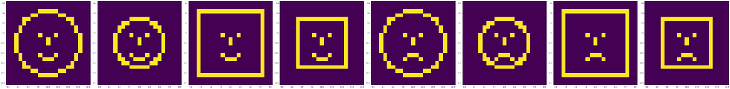

```python
fig, ax = plt.subplots(1,8,figsize=(60,60))
for i in range(8):
  ax[i].imshow(X[:,i:i+1].reshape(21,21), cmap='viridis')
plt.tight_layout()
```

1. While there are eight faces in this dataset, you will see that there are a smaller number of latent variables that are combined to “make up” one’s face. For example, I wouldn’t say the eyes and nose are one of the effective latent variables, because all have the same eyes and nose in this dataset. To identify those latent variables instead, you may want to figure out the combination of different parts of faces to reconstruct a face and examine all faces. What are the unique components that make up all the human faces effectively? This will define the number of latent variables K.
1. Based on your guess on the number of latent variables K, train a topic model. Don’t worry about using LDA, just a PLSI should work well. I recommend the first set of EM equations in M11-S18. PLSI will give you two matrices B ∈ R441×K and Θ ∈ RK×8. Since they are from “probabilistic” topic modeling, 441 Bf,k = 1 for any choice of k and K Θk,t = 1f=1 k=1 for any choice of t.

#### Update rule for B and Theta in PLSI

$ B = B \odot ( \frac{X}{B\Theta})\Theta^{T} $

$ \Theta = \Theta \odot (B^{T} \frac{X}{B\Theta} )$

$ B = \large \frac{B}{1^{v\times v}B}$

$ \theta = \large \frac{\theta}{1^{k\times k}\theta} $

```python
k = 6
#B = np.random.uniform(0,1,size=(441,k))
#theta = np.random.uniform(0,1,size=(k,8))

B = np.random.rand(441,k)
theta = np.random.rand(k,8)

one_B = np.ones((X.shape[0],X.shape[0]))
one_theta = np.ones((k,k))
for i in range(200):
    B_theta = (B @ theta) + 1e-10
    B_new = B * ((X/B_theta) @ theta.T)
    theta_new = theta * (B.T @ (X/B_theta))
    B = B_new/(one_B @ B_new)
    theta = theta_new/(one_theta @ theta_new )


#X_hat = B@theta
```

#### I have taken K = 6 as there 6 different element in all the 8 images

1. Draw your K basis images. Reshape each of B:,k back into a 21 × 21 2D array and show it as an image. Repeat it K times. That K images will show what the underlying face components are to make up the database, if your K is correct.

#### B images

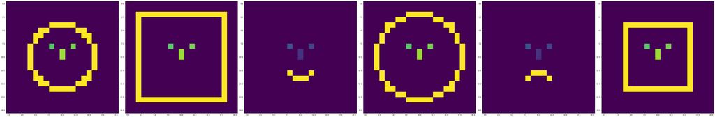

```python
fig, ax = plt.subplots(1,6,figsize=(60,60))
for i in range(6):
  ax[i].imshow(B[:,i:i+1].reshape(21,21), cmap='viridis')
plt.tight_layout()
```

1. Draw Θ as an image. Its column vector Θ:,t will tell you the probability of K basis images as to how much they contribute to reconstruct the t-th face.

#### Θ images

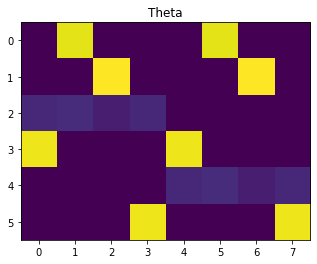

```python
plt.imshow(theta)
plt.title('Theta')
```

1. Draw your reconstructed facial images, i.e., X ≈ Xˆ = BΘ. Again, reshape each of Xˆ :,t back into a 21×21 2D array and show it as an image. Repeat it 8 times. These eight reconstructed images should be near-perfectly similar to those from X.
1. Note that the order of basis images can be shuffled, although it won’t affect your solution. The resulting images should be correct to receive full points.

#### X ≈ Xˆ = BΘ

```python
X_hat = B@theta
```

```python
X_hat.shape
```

```
(441, 8)
```

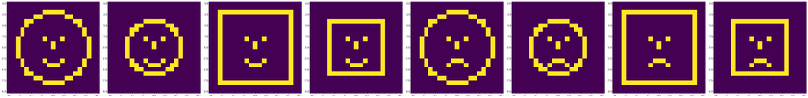

```python
fig, ax = plt.subplots(1,8,figsize=(60,60))
for i in range(8):
  ax[i].imshow(X_hat[:,i:i+1].reshape(21,21), cmap='viridis')
plt.tight_layout()
```

# P2: Stereo Matching (revisited)

1. You remember you did the GMM-based stereo matching, right? If you forgot, revisit Home- work 1 Problem 5.
1. Extend your implementation with the MRF’s smoothing priors using an eight neighborhood system (e.g. Ni,j = (i−1,j −1),(i−1,j),(i−1,j +1),(i,j −1),(i,j +1),(i+1,j −1),(i+ 1,j),(i+1,j+1). Feel free to choose either ICM or Gibbs sampling. Show me the smoothed results. You can use the Gaussian-kernel-looking prior probability equations discussed in class (M10 S8).

#### Import the image

```python
im_left = imread("im0.ppm")
im_right = imread("im8.ppm")
```

[figure not shown]

```python
fig = plt.figure(figsize = (10,6))

plt.subplot(1, 2, 1)
plt.imshow(im_left)
plt.title('Right Image')

plt.subplot(1, 2, 2)
plt.imshow(im_right)
plt.title('Left Image')
```

#### Disparity matrix

```python
Dis_mat = np.ones((im_left.shape[0],im_left.shape[1]-40))

for height in range(0,im_left.shape[0]):
    for width in range(0,im_left.shape[1]-40):
        #initialize some random value to calculate the minimum
        cost_int = im_left.shape[0]*1000

        for x in range(0,40):
            cost_fun = np.mean(np.square(im_right[height,width] - im_left[height,width+x]))
            if cost_fun < cost_int:
                cost_int = cost_fun
                Dis_mat[height,width] = x
```

```python
Dis_mat_flat = Dis_mat.flatten(order='C')
Dis_mat_flat.shape
```

```
(148590,)
```

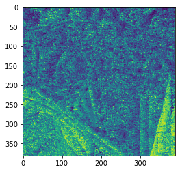

```python
plt.imshow(Dis_mat)
```

### GMM implementation

#### E step

```python
def gaussian_pdf(x,mu,var):
    return ((1/(2*np.pi*var)**0.5)*np.exp(-1/2*((x-mu)**2)*(1/var)))


def U_matrix(mu, var, x, P, n_centre = 4):
    U_mat = np.ones((x.shape[0],n_centre))

    for i in range(n_centre):
        U_mat[:,i] = gaussian_pdf(x,mu[:,i],var[:,i])

    U_mat = U_mat*P/(U_mat @ P.T)

    return U_mat
```

#### M- Step

```python
# updating mu
def mu_update(U, X):
    mu_new = np.sum(U*X.reshape(-1,1),axis=0)/np.sum(U,axis=0)
    return mu_new.reshape(1,-1)

# updating P
def P_update(U):
    P_new = np.sum(U, axis = 0)/U.shape[0]
    return P_new.reshape(1,-1)

# updating variance
def var_update(U, X, mu):
    var1 = np.ones((1,4))
    for i in range(var1.shape[1]):
       var1[:,i] = np.sum(U[:,i] * (X - mu[:,i])**2)/np.sum(U[:,i])
    return var1
```

```python
# initializing mu, var and P
mu =  np.array([random.uniform(min(Dis_mat_flat),max(Dis_mat_flat)) for _ in range(4)], dtype = float).reshape(1,-1)
var = np.array([random.uniform(0,2) for _ in range(4)], dtype = float).reshape(1,-1)
P = np.array([0.25,0.25,0.25,0.25])
P = P.reshape(1,-1)


for i in range(100):

    # executing the E step
    U = U_matrix(mu, var, Dis_mat_flat, P)
    # executing the M step
    mu = mu_update(U, Dis_mat_flat)
    P = P_update(U)
    var = var_update(U, Dis_mat_flat, mu)
```

```python
print("Mean values of the cluster",mu)
print("Variance of the cluster", var)
print("Probablities of the cluster", P)
```

```
Mean values of the cluster [[27.3022531  36.00107624 15.32743273  6.62428163]]
Variance of the cluster [[23.78774345  4.75642835 30.26215339 12.90955343]]
Probablities of the cluster [[0.22050884 0.06753046 0.27519287 0.43676784]]
```

#### Allocating the observation to the clusters

```python
cluster_allocation = np.ones(U.shape[0])
for i in range(U.shape[0]):
    cluster_allocation[i] = np.argmax(U[i])

(unique, counts) = np.unique(cluster_allocation, return_counts=True)
```

#### Size of cluster

```python
for i in range(4):
    print('Cluster size',i, counts[i])
```

```
Cluster size 0 32858
Cluster size 1 11617
Cluster size 2 34419
Cluster size 3 69696
```

#### Changing the pixel value to the cluster mean

```python
Dis_mat_flat1 = np.ones(Dis_mat_flat.shape[0])
for i in range(Dis_mat_flat.shape[0]):
    Dis_mat_flat1[i] = mu[:,int(cluster_allocation[i])]
```

#### GMM result

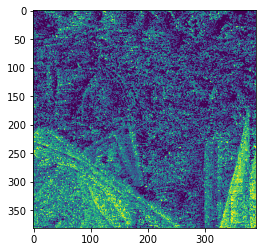

```python
plt.imshow(Dis_mat_flat1.reshape(381,390))
```

## ICM

#### Neighbours function

```python
def neighours_pixel(i,j):
    neighours=[(i-1, j -1), (i-1, j), (i-1, j +1), (i, j -1), (i, j+1), (i+1, j -1), (i+1, j), (i+1, j+1)]
    boundary = []
    for n in neighours:
        if 0<=n[0]<381 and  0<=n[1]<390:
            boundary.append(n)
    return boundary
```

#### Likelihood function

```python
# mu and var would be cluster which we calculated from GMM
def gaussian_pdf(x,mu,var):
    return ((1/(2*np.pi*var)**0.5)*np.exp(-1/2*((x-mu)**2)*(1/var)))
```

#### Prior function

```python
def prior_calculation(c1, c2, a=10 , sigma = 1):
    if c1 == c2:
        return 1
    else:
        return np.exp(-(a/sigma)**2)
```

#### ICM implementation

```python
centroid = np.unique(cluster_allocation)
cluster_allocation_matrix = np.copy(cluster_allocation.reshape(381,390))
img=np.ones((cluster_allocation_matrix.shape[0], cluster_allocation_matrix.shape[1]))


#iterating n times
for x in range(4):

    # iterating all the pixels
    for row in range(cluster_allocation_matrix.shape[0]):
        for col in range(cluster_allocation_matrix.shape[1]):

            # neighours of (row, col)
            neighours = neighours_pixel(row,col)

            posterior_class = []

            # four centers
            for c in centroid:

                #likelihood of each center
                likelihood = gaussian_pdf(Dis_mat[row,col], mu[:,int(c)], var[:,int(c)])

                # calculating prior of each neighbors and multiplying it
                prior= 1
                for n in neighours:

                    prior= prior*prior_calculation(c, cluster_allocation_matrix[n])

                # posterior probablity of each centre
                posterior_class.append(likelihood*prior)

            posterior_class = np.array(posterior_class)

            # selecting the center which has maximum posterity
            cluster_allocation_matrix[row, col] = np.argmax(posterior_class)
            #print(cluster_allocation_matrix)

            img[row, col] = mu[:,np.argmax(posterior_class)]
```

#### ICM result

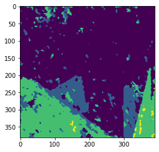

```python
plt.imshow(img)
```

# P3: Rock or Metal

1. trX.mat contains a matrix of size 2 × 160. Each of the column vectors holds “loudness” and “noisiness” features that describe a song. If the song is louder and noisier, it belongs to the “metal” class, and vice versa. trY.mat holds the labeling information of the songs: -1 for “rock”, +1 for “metal”.
1. Implement your own AdaBoost training algorithm. Train your model by adding weak learners. For your m-th weak learner, train a perceptron (no hidden layer) with the weighted error function:

   E(yt||yˆt) = wt(yt − yˆt)2,

   where wt is the weight applied to the t-th example after m − 1-th step. Note that yˆt is the output of your perceptron, whose activation function is tanh.
1. Implementation note: make sure that the m-th weak learner φm(x) is the sign of the percep- tron output, i.e. sgn(yˆt). What that means is, during training the m-th perceptron, you use yˆt as the output to calculate backpropagation error, but once the perceptron training is done, φm(xt) = sgn(yˆt), not φm(xt) = yˆt.
2. Don’t worry about testing the model on the test set. Instead, report a figure that shows the final weights over the examples (by changing the size of the markers), as well as the prediction of the models (giving different colors to the area). I’m expecting something similar to the ones in M12 S26.
3. Report your classification accuracy on the training samples, too.

```python
import scipy.io
trX = scipy.io.loadmat('trX.mat')['trX']
trY = scipy.io.loadmat('trY.mat')['trY']
```

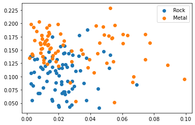

```python
plt.scatter(trX[0,:80],trX[1,:80],label='Rock');
plt.scatter(trX[0,80:],trX[1,80:],label='Metal');
plt.legend();
```

#### Error function for the perceptron

```python
def error_fun(ypred,w_ada):
    return w_ada*((trY - ypred)**2)
```

#### Derivative of error function

```python
def error_derivative_w(X_mat, w_ada, y_pred,Z):
    return (-2*w_ada*(trY - y_pred)* (1-np.tanh(Z)**2)) @ X_mat.T
```

#### Weak learner: Perceptron

```python
def perceptron(train, wt):
    ones = np.ones((1,train.shape[1]))
    X = np.empty((3, train.shape[1]))
    W = np.random.normal(0, 1, size=(1, 3))
    for i in range(1000):
        # forward propogation
        X[0:2] = train
        X[2] = ones
        Z= W @ X
        y_pred = np.tanh(Z)

        Error = error_fun(y_pred, wt)
        # backpropogation
        del_w = error_derivative_w(X, wt, y_pred, Z)
        W = W - (0.01 * del_w)
    return y_pred, W
```